# Practical Machine Learning Project: Weight Lifting Exercise

One thing that people regularly do is quantify how much of a particular activity they do, but they rarely quantify how well they do it. In this project, our goal is to use data from accelerometers on the belt, forearm, arm, and dumbell of 6 participants to predict the manner in which they did the exercise.

## Dataset

For this project, we use the [Weight Lifting Exercises Dataset](http://groupware.les.inf.puc-rio.br/har)

```r
wl.data <- read.csv("pml-training.csv", na.strings = c("","NA"))
dim(wl.data)
```

```
## [1] 19622   160
```

## Data Cleaning

There are some variables with many missing values. We will identify the corresponding columns and eliminate them.

```r
    ## Identify if variable contains NAs
    var.na <- apply(wl.data,2, function (x){
        any(is.na(x))
    })
```

From the 160 variables, 100 contain NAs. These variables refer to derived features of max, min, average, kurtosis, and skewness.

```r
    sum(var.na)
```

```
## [1] 100
```

```r
    names(var.na[var.na == T])[1:8]
```

```
## [1] "kurtosis_roll_belt"   "kurtosis_picth_belt"  "kurtosis_yaw_belt"
## [4] "skewness_roll_belt"   "skewness_roll_belt.1" "skewness_yaw_belt"
## [7] "max_roll_belt"        "max_picth_belt"
```

We subset only variables with complete cases.

```r
    wl.data <- wl.data[,var.na == F]
    dim(wl.data)
```

```
## [1] 19622    60
```

## Data Split

We split the data into training and testing sets.The training set will be used to build our model. Then, we evaluate the accuracy of our model predictions on the independent test set.

```r
    library(caret)
```

```r
    ## Random subsampling
    inTrain <- createDataPartition(y = wl.data$classe,
                                   p = 0.75, list = F)
    training <- wl.data[inTrain,]
    testing <- wl.data[-inTrain,]
    dim(training); dim(testing)
```

```
## [1] 14718    60
```

```
## [1] 4904   60
```

We can further subset to exclude variables not useful for prediction.

```r
    training <- training[,-c(1:7)]
    testing <- testing[,-c(1:7)]
    dim(training); dim(testing)
```

```
## [1] 14718    53
```

```
## [1] 4904   53
```

## Exploratory Analysis

We can take a look at the classification of exercises, the outcome we want to predict.

```r
    table(training$classe)
```

```
##
##    A    B    C    D    E
## 4185 2848 2567 2412 2706
```

We can also look at some plots to see the distribution of certain features among the five classes.

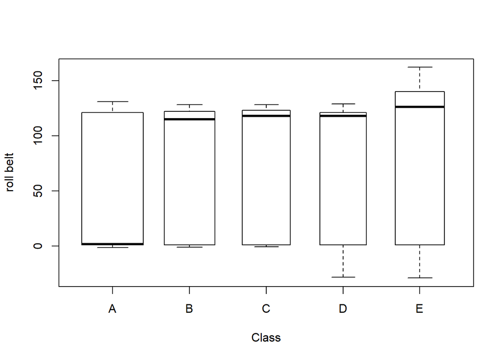

```r
    boxplot(roll_belt~ classe, data = training, varwidth=TRUE,
            xlab = "Class", ylab = "roll belt")
```

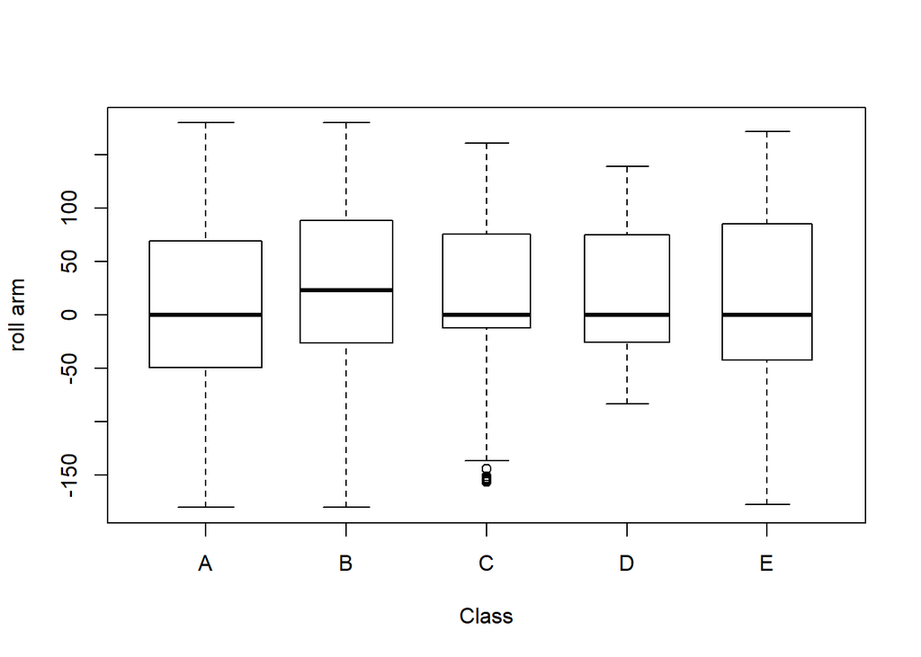

```r
    boxplot(roll_arm~ classe, data = training, varwidth=TRUE,
            xlab = "Class", ylab = "roll arm")
```

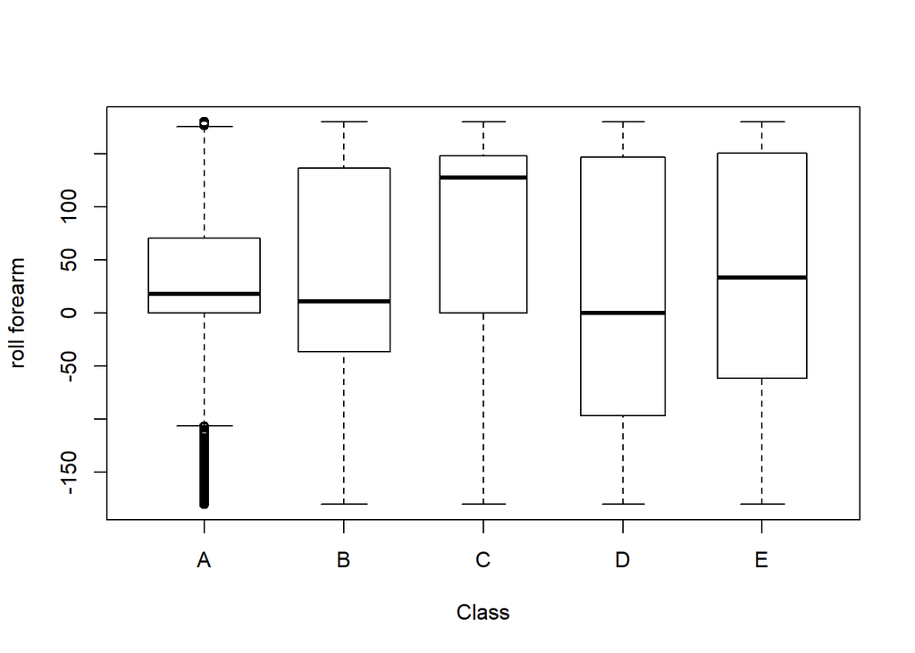

```r
   boxplot(roll_forearm~ classe, data = training, varwidth=TRUE,
            xlab = "Class", ylab = "roll forearm")
```

## Model Building: Random Forest

In order to predict the class of exercise, a random forest model is fitted to the training data. Random forest is chosen due to its high accuracy and because it is one of the top performing algorithms for prediction. To reduce the risk of overfitting, common in random forest models, is important to do cross-validation. Therefore, a five fold cross validation is implemented.

```r
    ## Cross-validation: 5-fold
    cv <- trainControl(method = "repeatedcv",
                               number = 5)
    ## Fitting Model
    rfMod <- train(classe ~ ., data = training, # data
                               method = "rf",   # Random Forest
                               trControl = cv,  # Cross-validation
                               ntree = 100)     # num. of trees
    rfMod$finalModel
```

```
##
## Call:
##  randomForest(x = x, y = y, ntree = 100, mtry = param$mtry)
##                Type of random forest: classification
##                      Number of trees: 100
## No. of variables tried at each split: 27
##
##         OOB estimate of  error rate: 0.68%
## Confusion matrix:
##      A    B    C    D    E  class.error
## A 4182    1    1    0    1 0.0007168459
## B   24 2814   10    0    0 0.0119382022
## C    0   14 2544    9    0 0.0089598753
## D    0    0   25 2385    2 0.0111940299
## E    0    0    6    7 2693 0.0048041390
```

## Predictions

We can then calculate the predicted values from our model and take a look at the classification table of predicted vs real values.

```r
    ## Get predictions on test set
    rf.predict <- predict(rfMod,testing)

    summary(rf.predict)
```

```
##    A    B    C    D    E
## 1398  951  864  790  901
```

```r
    ## Classification table
    table(rf.predict,testing$classe)
```

```
##
## rf.predict    A    B    C    D    E
##          A 1394    4    0    0    0
##          B    1  945    4    1    0
##          C    0    0  850   13    1
##          D    0    0    1  789    0
##          E    0    0    0    1  900
```

## Out-of-sample error and Accuracy

```r
    errors <- sum(rf.predict != testing$classe)
    errors
```

```
## [1] 26
```

```r
    errors/length(rf.predict)
```

```
## [1] 0.005301794
```

```r
    ## Confusion matrix
    confusionMatrix(testing$classe, rf.predict)
```

```
## Confusion Matrix and Statistics
##
##           Reference
## Prediction    A    B    C    D    E
##          A 1394    1    0    0    0
##          B    4  945    0    0    0
##          C    0    4  850    1    0
##          D    0    1   13  789    1
##          E    0    0    1    0  900
##
## Overall Statistics
##
##                Accuracy : 0.9947
##                  95% CI : (0.9922, 0.9965)
##     No Information Rate : 0.2851
##     P-Value [Acc > NIR] : < 2.2e-16
##
##                   Kappa : 0.9933
##  Mcnemar's Test P-Value : NA
##
## Statistics by Class:
##
##                      Class: A Class: B Class: C Class: D Class: E
## Sensitivity            0.9971   0.9937   0.9838   0.9987   0.9989
## Specificity            0.9997   0.9990   0.9988   0.9964   0.9998
## Pos Pred Value         0.9993   0.9958   0.9942   0.9813   0.9989
## Neg Pred Value         0.9989   0.9985   0.9965   0.9998   0.9998
## Prevalence             0.2851   0.1939   0.1762   0.1611   0.1837
## Detection Rate         0.2843   0.1927   0.1733   0.1609   0.1835
## Detection Prevalence   0.2845   0.1935   0.1743   0.1639   0.1837
## Balanced Accuracy      0.9984   0.9963   0.9913   0.9975   0.9993
```